# How Often Does the Better Team Win the World Series?

Can Luo

9/8/2019

The world series is a best-of-7 match-up between the champions of the American and National Leagues of Major League Baseball. The competence of a team can be specified by the probability of winning in a single game.If we collect a team’s past game records , we can get a general winning probability of that team. Then, using statistical theory , we can get a lot of predictions and insights about the game.

Let’s see how statistics and probability works in games prediction and how often the better team win the world series through an example of the Braves and the Yankees.

# 1 Basic Supposing

1.Braves and the Yankees are teams competing in the World Series.

2.In any given game, the probability that the Braves win is PB and the probability that the Yankees win is PY=1-PB.

# 2 Prediction and Analysis

## 2.1 Prediction I

What is the probability that the Braves win the World Series given that PB=0.55?

```r
pb<-0.55
py<-1-pb
winprob<-function(p,l) {
  w=ceiling(l/2)
  wp<-0
  for (f in 0:l-w){
    wp<-wp+dnbinom(f,w,p)}
  wp
}
pbwin<-winprob(pb,7)
```

And the answer is 0.6082878.

## 2.2 Prediction II

What is the probability that the Braves win the World Series given that PB=x?

Changing the value of PB, repeating the process above and making a graph,we can see the output below.

```r
pb<-0.01*seq(1:100)
pwin<-rep(NA,100)
for (i in seq_along(pwin)){
  pwin[i]<-winprob(pb[i],7)
}
plot.new()
plot.window(xlim=range(pb),ylim=range(pwin))
```

```r
lines(pb,pwin,pch=5,lwd=1,col="red",type="l",text(1,0.95,"y=x"))
lines(pb,pb,type="l")
```

```r
axis(1)
axis(2)
```

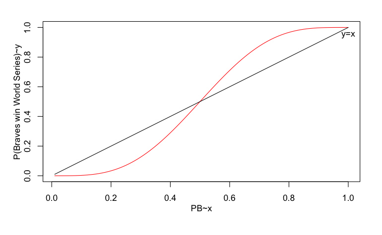

```r
box()
title(xlab = "PB~x", ylab = "P(Braves win World Series)~y", line = 2)
```

```r
d<-data.frame(pb=pb,pwin=pwin)
```

We can see from the figure that in best-of-7 series, the worse team(PB<0.5), has less probability to win the series than win a single game. The better team(PB>0.5)’s advantage is enhanced in best-of-7 series. This demonstrates that best-of-7 can distinguish good team from bad team.

## 2.3 Prediction III

Suppose one could change the World Series to be best-of-9 or some other best-of-X series. What is the shortest series length so that P(Braves win World Series|PB=.55)≥0.8?

Based on the X must be an odd number and more than 1, we do the test below in function ‘shortest’.

```r
shortest<-function(p,trynumber,pt){
  for (i in seq_along(trynumber)){
  pwin<-winprob(p,trynumber[i])
  if (pwin>=pt){return(trynumber[i])}
  }
}
shortest(0.55,l<-seq(1:100)*2+1,0.8)
```

```
[1] 71
```

best-of-71 is the shortest length which can make the probabilty of brave’s winning larger than 0.8.

## 2.4 Prediction IV

What is the shortest series length so that P(Braves win World Series|PB=x)≥0.8?

To solve this, firstly let us do a pre-experiment about PB , P(Braves win ) and best-of-X.

```r
#testp is a function to explore the relationship between P(Braves win World Series) and best-of-x  in defferent PB
testp <- function(pb, m) {
  l <- seq(1:m) * 2 + 1
  pwin <- rep(NA, m)
  for (i in seq_along(pwin)) {
    pwin[i] <- winprob(pb, l[i])
  }
  best_of_x <- l
  plot.new()
  plot.window(xlim = range(l), ylim = range(pwin))
  lines(l,
        pwin,
        pch = 5,
        lwd = 1,
        col = "red")
  text(2, pwin[4], paste("PB=", as.character(pb)), pos = 4)
  axis(1)
  axis(2)
  box()
  title(xlab = "best-of-x" ,
        ylab = "P(Braves win)" ,
        line = 2)
}
par(mfrow=c(2,3))
testp(0.20,100)
testp(0.40,100)
```

```r
testp(0.50,100)
testp(0.51,100)
```

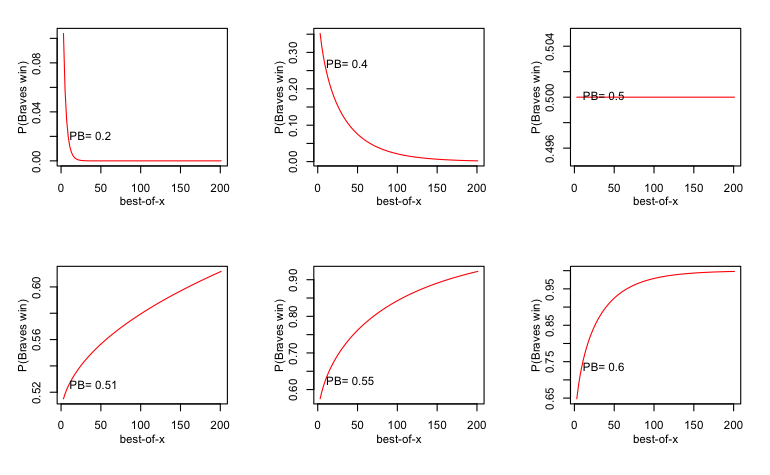

```r
testp(0.55,100)
testp(0.60,100)
```

```r
NA
NA
NA
```

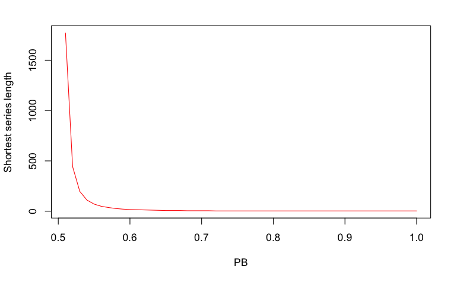

```r
pb<-0.01*seq(1:50)+0.5
sl<-rep(NA,50)
l<-seq(1:1000)*2+1
for (i in seq_along(pb)){
  sl[i]<-shortest(pb[i],l,0.8)
}
d<-data.frame(pb=pb,shortestlength=sl)
plot(d,ylab="Shortest series length",ylim=range(sl),xlab="PB",xlim=range(pb),type="l",col="red")
```

When PB increase, the shortest series length to make P(Braves win)>=0.8 is declining to 3.

## 2.5 Prediction V

What is the value of P(PB=0.55|Braves win World Series in 7 games) under the assumption that either PB=0.55 or PB=0.45?

From Bayes Rule, we can know that:

P(braves win in 7 games)=P(braves win in 7 games|PB=0.45)*P(PB=0.45)+P(braves win in 7 games|PB=0.55)*P(PB=0.55)

P(PB=0.55|braves win world series in 7 games)=P(braves win in 7 games|PB=0.55)*P(PB=0.55)/P(braves win in 7 games)

However, we do not know the value of P(PB=0.55). What I can present is a graph which shows different value of P(PB=0.55|Braves win World Series in 7 games) according to different P(PB=0.55).

```r
#p55: P(PB=0.55)
#p45: P(PB=0.45)
#p55+p45=1
p55<-0.01*seq(1:100)
p<-rep(NA,length(p55))
for (i in seq_along(p55)){
p[i]<-dnbinom(3,4,0.55)*p55[i]/(dnbinom(3,4,0.55)*p55[i]+dnbinom(3,4,0.45)*(1-p55[i]))
}
#plot(p55,p)
d<-data.frame(p55=p55,p=p)
plot.new()
plot.window(xlim=range(p55),ylim=range(p))
```

```r
lines(p55,p,pch=5,lwd=1,col="red",type="p")
axis(1)
```

```r
axis(2)
box()
```

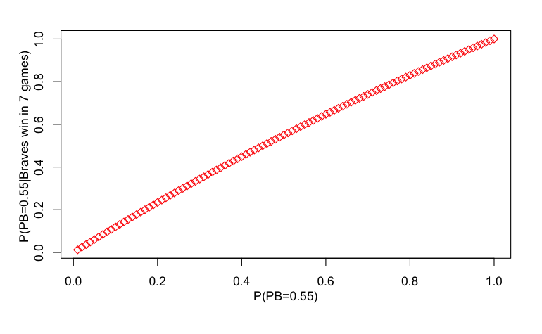

```r
title(xlab = "P(PB=0.55)", ylab = "P(PB=0.55|Braves win in 7 games) ", line = 2)
```

The line is slightly curly, not 100% linear.

# 3 Conclusion

1. Best-of-x game is a fair format of competition, since the better team always own more possibility to win.
2. We can use the genneral winning probability to recommand a desirable length of game for a team.
3. When the length of games increases, the better team seems to win with more possibility , which complies to our common sense.
4. When the length of games is less than 7, the real competence of a better team is hard to show off(eg: Prediction IV , graphs of pre-test). Hence, to be fair, at least a best-of-7 series are neccessary to judge two teams.